# FIFA Players Position Categorization

Objective

In this part of the project we aim to use Machine Learning in order to create a model to predict football players position based on their physical attributes.

Background

Football is the most popular sport in the world. A recent FIFA (Fédération Internationale de Football Association) survey indicates that there are more than 300 Million football players around the world and an estimated fan base of over 3.5 Billion people.

A football match is played between 2 teams of eleven players, each one with an specific position. Since its invention the game has evolved to have more specialized roles for the different types of players, resulting on 25 different positions, however these can be grouped in 4 main categories.

1. Striker or Forward - whose main task is to score goal.
2. Midfielders - who dispossess the opposition and keep possession of the ball to pass it to the forwards on their team.
3. Defender - who specialize in preventing their opponents from scoring.
4. Goalkeeper – who is an specific type of defenders in charge of secure the goal, the only position in this game who is allowed to touch the ball with its hands.

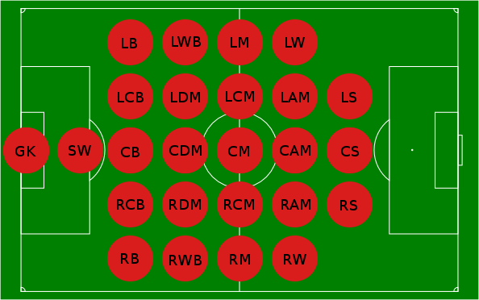

For this project we use a FIFA video game datasets which are available in Kaggle datasets (https://www.kaggle.com/karangadiya/fifa19). These data sets contain the categorical information that defines each of the FIFA Professional players position and a set of variables that represents their physical attributes. We’ve selected FIFA 2015 dataset, which contains over 14k records and more than 105 data elements, each one pertaining to an specific professional Football player in a CSV file.

We have filtered the information to keep only the data related to physical attributes (75 data elements) and 1 field containing the information of the player position in their current clubs, which will be used as the categorical variable. The data was prepared as below

1. Removing rows with null values on the player position field.
2. Removing columns with non-numerical values from the physical attributes.
3. Replacing null values with zeros in the physical attributes.

For the first exercise we will use only 2 physical data attributes which are heavily correlated – Stamina and Strength – we will fit the model with these 2 variables as independent variables (X) in order to train a Keras Sequential model to predict the player position (dependent variable y) based on these 2 physical attributes.

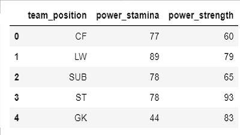

Using this configuration we had 22 diferent classes for the model, each one of the different player positon variants. After fiting the model with 1000 Epoch. The results were not as good as we expected as after validating the model with our testing data was the accuaracy obtained was 0.26

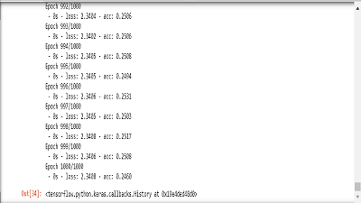

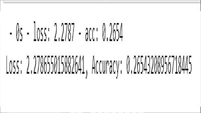

The results can be attributed to the significant number of classes, the 22 varainces of the main 4 positions categories with the limited number of physical attributes are leading the model to these results.

In order to prove this we decided to run the model with the same 2 independent variables, but in this ocasion we have grouped the 22 classes in to the 4 main positon categories, having only Striker, Deffender, Midfielder and GoalKepper.

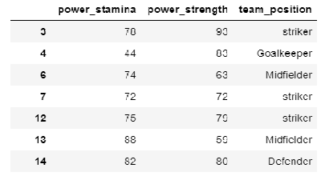

With this change and the same model configuration but changing the classes from 22 to 4 the results improved significantly resulting on an accuracy of 0.62.

[figure not shown]

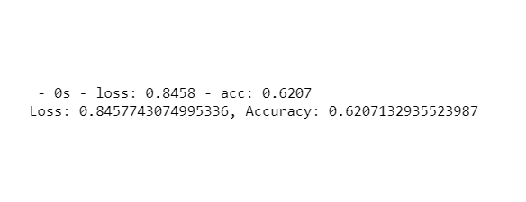

In order to improve the model we will increase the number of variables, from 2 to 75. Eeach one of this variable is more related to a specific position. i.e. an Striker would have more shooting power whereas a the defense skills are stronger on a Deffender.

After fiting the model whith the additional variables we can see a signficant improvemnet as the accuracy tested validated with the testing data resulted in 0.86.

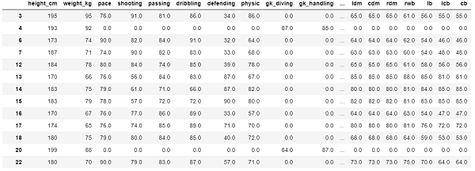

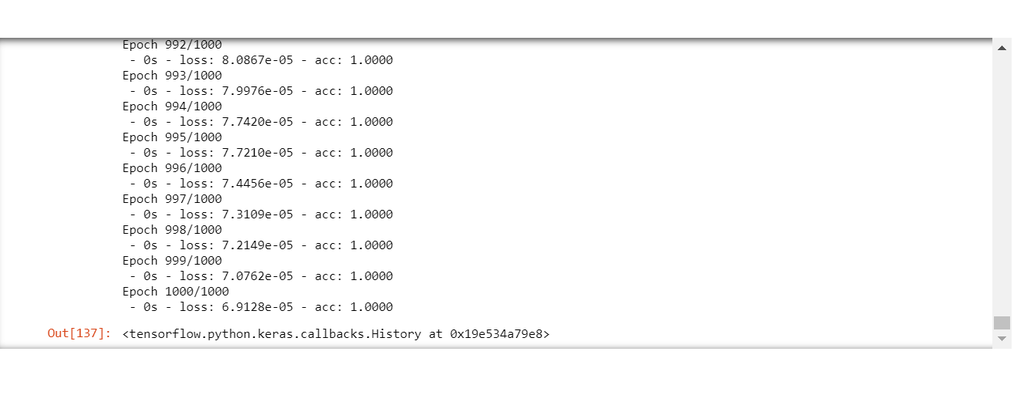

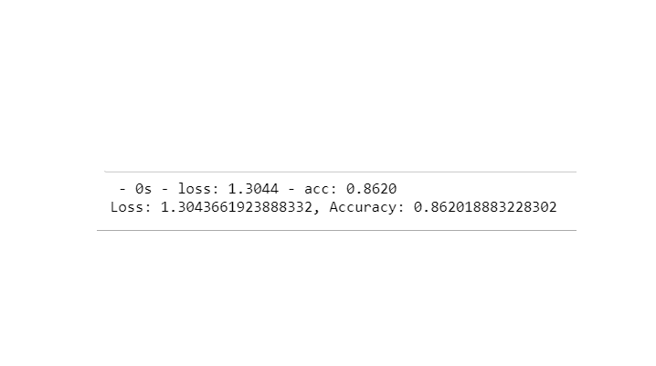